# R Notebook-ANZ

```r
rm(list=ls())
library(readxl)
library(dplyr)
library(tidyverse)
library(visdat)
```

```r
library(ggplot2)
library(cluster)
library(factoextra)
ANZ_dataset <- read_excel("D:/ANZ/ANZ synthesised transaction dataset.xlsx")
attach(ANZ_dataset)
#View(ANZ_dataset)
ANZ_dataset$date<- as.Date(date)
str(ANZ_dataset)
```

```
## tibble [12,043 x 23] (S3: tbl_df/tbl/data.frame)
##  $ status           : chr [1:12043] "authorized" "authorized" "authorized" "authorized" ...
##  $ card_present_flag: num [1:12043] 1 0 1 1 1 NA 1 1 1 NA ...
##  $ bpay_biller_code : num [1:12043] NA NA NA NA NA NA NA NA NA NA ...
##  $ account          : chr [1:12043] "ACC-1598451071" "ACC-1598451071" "ACC-1222300524" "ACC-1037050564" ...
##  $ currency         : chr [1:12043] "AUD" "AUD" "AUD" "AUD" ...
##  $ long_lat         : chr [1:12043] "153.41 -27.95" "153.41 -27.95" "151.23 -33.94" "153.10 -27.66" ...
##  $ txn_description  : chr [1:12043] "POS" "SALES-POS" "POS" "SALES-POS" ...
##  $ merchant_id      : chr [1:12043] "81c48296-73be-44a7-befa-d053f48ce7cd" "830a451c-316e-4a6a-bf25-e37caedca49e" "835c231d-8cdf-4e96-859d-e9d571760cf0" "48514682-c78a-4a88-b0da-2d6302e64673" ...
##  $ merchant_code    : num [1:12043] NA NA NA NA NA NA NA NA NA NA ...
##  $ first_name       : chr [1:12043] "Diana" "Diana" "Michael" "Rhonda" ...
##  $ balance          : num [1:12043] 35.39 21.2 5.71 2117.22 17.95 ...
##  $ date             : Date[1:12043], format: "2018-08-01" "2018-08-01" ...
##  $ gender           : chr [1:12043] "F" "F" "M" "F" ...
##  $ age              : num [1:12043] 26 26 38 40 26 20 43 43 27 40 ...
##  $ merchant_suburb  : chr [1:12043] "Ashmore" "Sydney" "Sydney" "Buderim" ...
##  $ merchant_state   : chr [1:12043] "QLD" "NSW" "NSW" "QLD" ...
##  $ extraction       : chr [1:12043] "2018-08-01T01:01:15.000+0000" "2018-08-01T01:13:45.000+0000" "2018-08-01T01:26:15.000+0000" "2018-08-01T01:38:45.000+0000" ...
##  $ amount           : num [1:12043] 16.25 14.19 6.42 40.9 3.25 ...
##  $ transaction_id   : chr [1:12043] "a623070bfead4541a6b0fff8a09e706c" "13270a2a902145da9db4c951e04b51b9" "feb79e7ecd7048a5a36ec889d1a94270" "2698170da3704fd981b15e64a006079e" ...
##  $ country          : chr [1:12043] "Australia" "Australia" "Australia" "Australia" ...
##  $ customer_id      : chr [1:12043] "CUS-2487424745" "CUS-2487424745" "CUS-2142601169" "CUS-1614226872" ...
##  $ merchant_long_lat: chr [1:12043] "153.38 -27.99" "151.21 -33.87" "151.21 -33.87" "153.05 -26.68" ...
##  $ movement         : chr [1:12043] "debit" "debit" "debit" "debit" ...
```

```r
summary(ANZ_dataset)
```

```
##     status          card_present_flag bpay_biller_code   account
##  Length:12043       Min.   :0.000     Min.   :0        Length:12043
##  Class :character   1st Qu.:1.000     1st Qu.:0        Class :character
##  Mode  :character   Median :1.000     Median :0        Mode  :character
##                     Mean   :0.803     Mean   :0
##                     3rd Qu.:1.000     3rd Qu.:0
##                     Max.   :1.000     Max.   :0
##                     NA's   :4326      NA's   :11160
##    currency           long_lat         txn_description    merchant_id
##  Length:12043       Length:12043       Length:12043       Length:12043
##  Class :character   Class :character   Class :character   Class :character
##  Mode  :character   Mode  :character   Mode  :character   Mode  :character
##
##
##
##
##  merchant_code    first_name           balance               date
##  Min.   :0       Length:12043       Min.   :     0.24   Min.   :2018-08-01
##  1st Qu.:0       Class :character   1st Qu.:  3158.59   1st Qu.:2018-08-24
##  Median :0       Mode  :character   Median :  6432.01   Median :2018-09-16
##  Mean   :0                          Mean   : 14704.20   Mean   :2018-09-15
##  3rd Qu.:0                          3rd Qu.: 12465.94   3rd Qu.:2018-10-09
##  Max.   :0                          Max.   :267128.52   Max.   :2018-10-31
##  NA's   :11160
##     gender               age        merchant_suburb    merchant_state
##  Length:12043       Min.   :18.00   Length:12043       Length:12043
##  Class :character   1st Qu.:22.00   Class :character   Class :character
##  Mode  :character   Median :28.00   Mode  :character   Mode  :character
##                     Mean   :30.58
##                     3rd Qu.:38.00
##                     Max.   :78.00
##
##   extraction            amount        transaction_id       country
##  Length:12043       Min.   :   0.10   Length:12043       Length:12043
##  Class :character   1st Qu.:  16.00   Class :character   Class :character
##  Mode  :character   Median :  29.00   Mode  :character   Mode  :character
##                     Mean   : 187.93
##                     3rd Qu.:  53.66
##                     Max.   :8835.98
##
##  customer_id        merchant_long_lat    movement
##  Length:12043       Length:12043       Length:12043
##  Class :character   Class :character   Class :character
##  Mode  :character   Mode  :character   Mode  :character
##
##
##
##
```

```r
#convert character to factor columns

fact_cols <- names(dplyr::select_if(subset(ANZ_dataset,select = -c(account,long_lat,merchant_id,first_name,extraction,transaction_id,customer_id,merchant_long_lat)), is_character))
ANZ_dataset[,fact_cols] <- lapply(ANZ_dataset[,fact_cols], factor)
str(ANZ_dataset)
```

```
## tibble [12,043 x 23] (S3: tbl_df/tbl/data.frame)
##  $ status           : Factor w/ 2 levels "authorized","posted": 1 1 1 1 1 2 1 1 1 2 ...
##  $ card_present_flag: num [1:12043] 1 0 1 1 1 NA 1 1 1 NA ...
##  $ bpay_biller_code : num [1:12043] NA NA NA NA NA NA NA NA NA NA ...
##  $ account          : chr [1:12043] "ACC-1598451071" "ACC-1598451071" "ACC-1222300524" "ACC-1037050564" ...
##  $ currency         : Factor w/ 1 level "AUD": 1 1 1 1 1 1 1 1 1 1 ...
##  $ long_lat         : chr [1:12043] "153.41 -27.95" "153.41 -27.95" "151.23 -33.94" "153.10 -27.66" ...
##  $ txn_description  : Factor w/ 6 levels "INTER BANK","PAY/SALARY",..: 5 6 5 6 6 3 6 5 5 1 ...
##  $ merchant_id      : chr [1:12043] "81c48296-73be-44a7-befa-d053f48ce7cd" "830a451c-316e-4a6a-bf25-e37caedca49e" "835c231d-8cdf-4e96-859d-e9d571760cf0" "48514682-c78a-4a88-b0da-2d6302e64673" ...
##  $ merchant_code    : num [1:12043] NA NA NA NA NA NA NA NA NA NA ...
##  $ first_name       : chr [1:12043] "Diana" "Diana" "Michael" "Rhonda" ...
##  $ balance          : num [1:12043] 35.39 21.2 5.71 2117.22 17.95 ...
##  $ date             : Date[1:12043], format: "2018-08-01" "2018-08-01" ...
##  $ gender           : Factor w/ 2 levels "F","M": 1 1 2 1 1 2 1 1 1 2 ...
##  $ age              : num [1:12043] 26 26 38 40 26 20 43 43 27 40 ...
##  $ merchant_suburb  : Factor w/ 1609 levels "Abbotsford","Aberdeen",..: 53 1380 1380 215 902 NA 709 893 1602 NA ...
##  $ merchant_state   : Factor w/ 8 levels "ACT","NSW","NT",..: 4 2 2 4 4 NA 7 7 8 NA ...
##  $ extraction       : chr [1:12043] "2018-08-01T01:01:15.000+0000" "2018-08-01T01:13:45.000+0000" "2018-08-01T01:26:15.000+0000" "2018-08-01T01:38:45.000+0000" ...
##  $ amount           : num [1:12043] 16.25 14.19 6.42 40.9 3.25 ...
##  $ transaction_id   : chr [1:12043] "a623070bfead4541a6b0fff8a09e706c" "13270a2a902145da9db4c951e04b51b9" "feb79e7ecd7048a5a36ec889d1a94270" "2698170da3704fd981b15e64a006079e" ...
##  $ country          : Factor w/ 1 level "Australia": 1 1 1 1 1 1 1 1 1 1 ...
##  $ customer_id      : chr [1:12043] "CUS-2487424745" "CUS-2487424745" "CUS-2142601169" "CUS-1614226872" ...
##  $ merchant_long_lat: chr [1:12043] "153.38 -27.99" "151.21 -33.87" "151.21 -33.87" "153.05 -26.68" ...
##  $ movement         : Factor w/ 2 levels "credit","debit": 2 2 2 2 2 2 2 2 2 2 ...
```

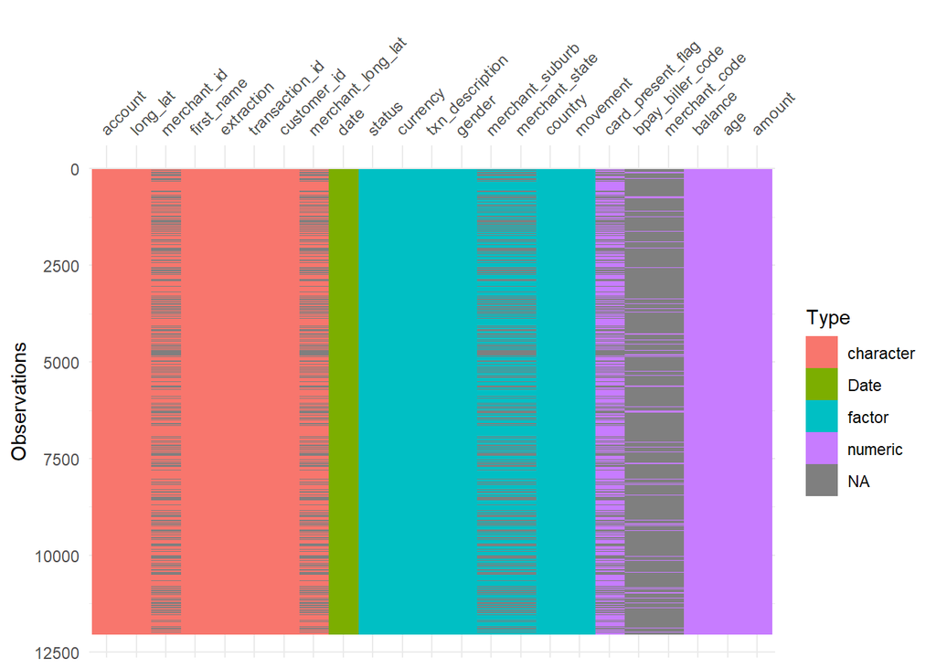

```r
vis_dat(ANZ_dataset)
```

bpay_biller_code and merchant_code has 92.67% missingness in data and hence can be removed From the vismiss plot, we can observe that for the rest of the columns containing missing values, all values missing are from the same rows and all these columns have 35.92% of missing data (4326 rows)

```r
ANZ_dataset <- subset(ANZ_dataset, select = -c(bpay_biller_code,merchant_code))
lapply(ANZ_dataset,function(x) { length(which(is.na(x)))})
```

```
## $status
## [1] 0
##
## $card_present_flag
## [1] 4326
##
## $account
## [1] 0
##
## $currency
## [1] 0
##
## $long_lat
## [1] 0
##
## $txn_description
## [1] 0
##
## $merchant_id
## [1] 4326
##
## $first_name
## [1] 0
##
## $balance
## [1] 0
##
## $date
## [1] 0
##
## $gender
## [1] 0
##
## $age
## [1] 0
##
## $merchant_suburb
## [1] 4326
##
## $merchant_state
## [1] 4326
##
## $extraction
## [1] 0
##
## $amount
## [1] 0
##
## $transaction_id
## [1] 0
##
## $country
## [1] 0
##
## $customer_id
## [1] 0
##
## $merchant_long_lat
## [1] 4326
##
## $movement
## [1] 0
```

```r
head(ANZ_dataset)
```

| status | card_present_flag | account | currency | long_lat | txn_description | merchant_id | first_name | balance | date | gender | age | merchant_suburb | merchant_state | extraction | amount | transaction_id | country | customer_id | merchant_long_lat | movement |
| --- | --- | --- | --- | --- | --- | --- | --- | --- | --- | --- | --- | --- | --- | --- | --- | --- | --- | --- | --- | --- |
| authorized | 1 | ACC-1598451071 | AUD | 153.41 -27.95 | POS | 81c48296-73be-44a7-befa-d053f48ce7cd | Diana | 35.39 | 2018-08-01 | F | 26 | Ashmore | QLD | 2018-08-01T01:01:15.000+0000 | 16.25 | a623070bfead4541a6b0fff8a09e706c | Australia | CUS-2487424745 | 153.38 -27.99 | debit |
| authorized | 0 | ACC-1598451071 | AUD | 153.41 -27.95 | SALES-POS | 830a451c-316e-4a6a-bf25-e37caedca49e | Diana | 21.20 | 2018-08-01 | F | 26 | Sydney | NSW | 2018-08-01T01:13:45.000+0000 | 14.19 | 13270a2a902145da9db4c951e04b51b9 | Australia | CUS-2487424745 | 151.21 -33.87 | debit |
| authorized | 1 | ACC-1222300524 | AUD | 151.23 -33.94 | POS | 835c231d-8cdf-4e96-859d-e9d571760cf0 | Michael | 5.71 | 2018-08-01 | M | 38 | Sydney | NSW | 2018-08-01T01:26:15.000+0000 | 6.42 | feb79e7ecd7048a5a36ec889d1a94270 | Australia | CUS-2142601169 | 151.21 -33.87 | debit |
| authorized | 1 | ACC-1037050564 | AUD | 153.10 -27.66 | SALES-POS | 48514682-c78a-4a88-b0da-2d6302e64673 | Rhonda | 2117.22 | 2018-08-01 | F | 40 | Buderim | QLD | 2018-08-01T01:38:45.000+0000 | 40.90 | 2698170da3704fd981b15e64a006079e | Australia | CUS-1614226872 | 153.05 -26.68 | debit |
| authorized | 1 | ACC-1598451071 | AUD | 153.41 -27.95 | SALES-POS | b4e02c10-0852-4273-b8fd-7b3395e32eb0 | Diana | 17.95 | 2018-08-01 | F | 26 | Mermaid Beach | QLD | 2018-08-01T01:51:15.000+0000 | 3.25 | 329adf79878c4cf0aeb4188b4691c266 | Australia | CUS-2487424745 | 153.44 -28.06 | debit |
| posted | NA | ACC-1608363396 | AUD | 151.22 -33.87 | PAYMENT | NA | Robert | 1705.43 | 2018-08-01 | M | 20 | NA | NA | 2018-08-01T02:00:00.000+0000 | 163.00 | 1005b48a6eda4ffd85e9b649dc9467d3 | Australia | CUS-2688605418 | NA | debit |

```r
ANZ_dataset %>% filter(is.na(card_present_flag)) %>% filter(status=="posted") %>% count()
```

| n |
| --- |
| 4326 |

```r
ANZ_dataset  %>% filter(status=="posted") %>% count()
```

| n |
| --- |
| 4326 |

We can verify from above code that the missing values for the 5 columns are when the status is “posted” Data does not need to be cleansed as merchant details will be NA for posted transactions ##Explanatory analysis There are 100 customer out of which 20 has the same customer first name

```r
unique(ANZ_dataset$first_name)
```

```
##  [1] "Diana"       "Michael"     "Rhonda"      "Robert"      "Kristin"
##  [6] "Tonya"       "Fernando"    "Isaiah"      "Ricky"       "Jeffrey"
## [11] "Patrick"     "Karen"       "Ruth"        "Kimberly"    "Joseph"
## [16] "Tiffany"     "Emily"       "Christine"   "Ryan"        "Michelle"
## [21] "Richard"     "Jessica"     "Ronald"      "Kaitlyn"     "Lori"
## [26] "Virginia"    "Andrew"      "Susan"       "Luis"        "Gregory"
## [31] "Barry"       "Daniel"      "Renee"       "Amy"         "Christopher"
## [36] "Marissa"     "Eric"        "Natasha"     "Edward"      "Craig"
## [41] "Sandra"      "Debra"       "Michele"     "Antonio"     "Tyler"
## [46] "Lucas"       "Jonathan"    "Matthew"     "James"       "Mackenzie"
## [51] "Linda"       "Dustin"      "Heather"     "Derek"       "Scott"
## [56] "Charles"     "Tim"         "Melissa"     "Darren"      "Jacqueline"
## [61] "Cindy"       "Stephanie"   "Rachael"     "Mary"        "Maria"
## [66] "Timothy"     "Nathaniel"   "Elizabeth"   "Paul"        "Sarah"
## [71] "Alexander"   "Donald"      "Kenneth"     "Ashley"      "Catherine"
## [76] "Billy"       "Abigail"     "Brian"       "David"       "Robin"
```

Michael is the most common first name, and has 6 different account users

```r
ANZ_dataset %>% group_by(first_name)%>% summarise(unique(account)) %>% count() %>% filter(n>1)
```

| first_name | n |
| --- | --- |
| Christopher | 2 |
| Eric | 2 |
| Jeffrey | 2 |
| Jessica | 2 |
| Joseph | 2 |
| Kenneth | 2 |
| Kimberly | 3 |
| Linda | 2 |
| Michael | 6 |
| Richard | 3 |

[output cut: 4 more lines]

```r
#Defining Age Group
ANZ_dataset1 <-mutate(ANZ_dataset,Age_group = ifelse(age <= 30 ,'teenage',ifelse(age >30 & age <50, 'midage','old')))
#monthly salary
ANZ_dataset2<-ANZ_dataset1 %>% group_by(account,first_name,format(date, "%m"),format(date, "%Y"),movement)%>% summarise(sum(amount))
```

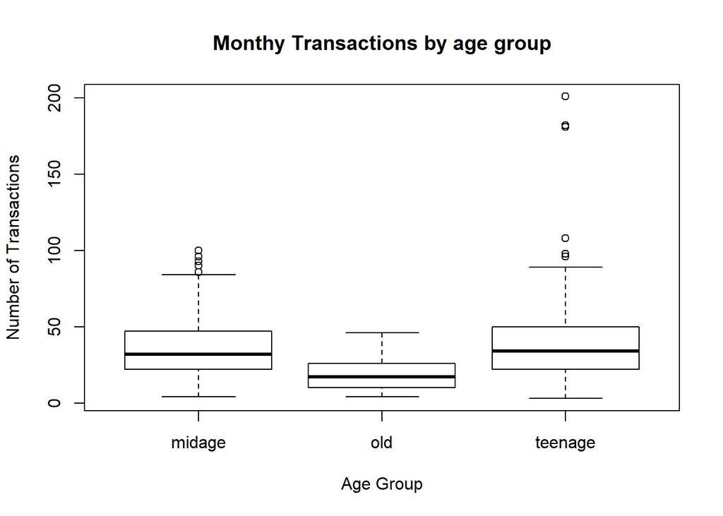

```r
ANZ_dataset2<- ANZ_dataset2 %>% rename( month = "format(date, \"%m\")" ,year = "format(date, \"%Y\")",total_amount="sum(amount)" )

#Total number of Transactions per month excluding credit
AnZ2 <-ANZ_dataset1 %>% filter(movement!='credit')%>% group_by(account,first_name,format(date, "%m/%Y"),Age_group,gender)%>% count()
#outlier analysis
boxplot(AnZ2$n ~ AnZ2$Age_group,xlab = "Age Group",ylab = "Number of Transactions", main = "Monthy Transactions by age group")
```

```r
out <-boxplot.stats(AnZ2$n)$out
out_ind <- which(AnZ2$n %in% c(out))
AnZ2[out_ind, ]
```

| account | first_name | format(date, "%m/%Y") | Age_group | gender | n |
| --- | --- | --- | --- | --- | --- |
| ACC-1037050564 | Rhonda | 09/2018 | midage | F | 93 |
| ACC-1222300524 | Michael | 08/2018 | midage | M | 90 |
| ACC-1222300524 | Michael | 09/2018 | midage | M | 100 |
| ACC-1222300524 | Michael | 10/2018 | midage | M | 100 |
| ACC-1598451071 | Diana | 08/2018 | teenage | F | 182 |
| ACC-1598451071 | Diana | 09/2018 | teenage | F | 181 |
| ACC-1598451071 | Diana | 10/2018 | teenage | F | 201 |
| ACC-182446574 | Tonya | 08/2018 | teenage | F | 108 |
| ACC-182446574 | Tonya | 10/2018 | teenage | F | 98 |
| ACC-1903037542 | Jeffrey | 10/2018 | teenage | M | 89 |

[output cut: 3 more lines]

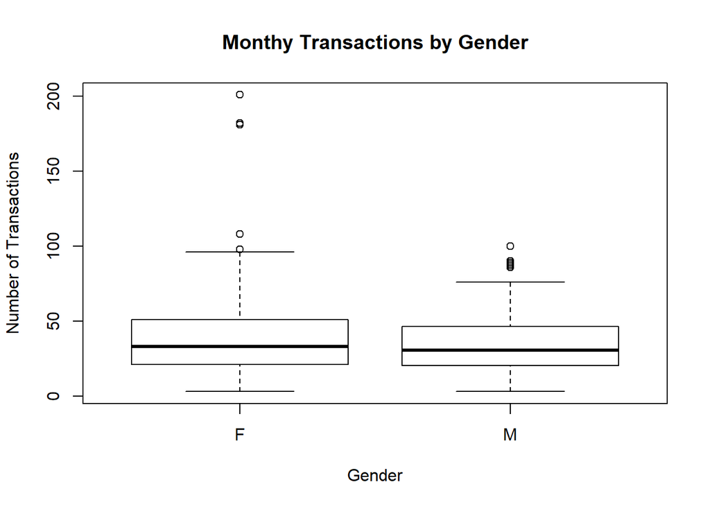

```r
boxplot(AnZ2$n ~ AnZ2$gender,xlab = "Gender",ylab = "Number of Transactions", main = "Monthy Transactions by Gender")
```

```r
ANZ_cred<-ANZ_dataset1 %>%filter(movement=='credit')%>% group_by(account,first_name,format(date, "%m/%Y")) %>%summarise(sum(amount)) %>%rename(credit="sum(amount)")
ANZ_debit<-ANZ_dataset1 %>%filter(movement=='debit')%>% group_by(account,first_name,format(date, "%m/%Y")) %>%summarise(sum(amount)) %>%rename(debit="sum(amount)")
```

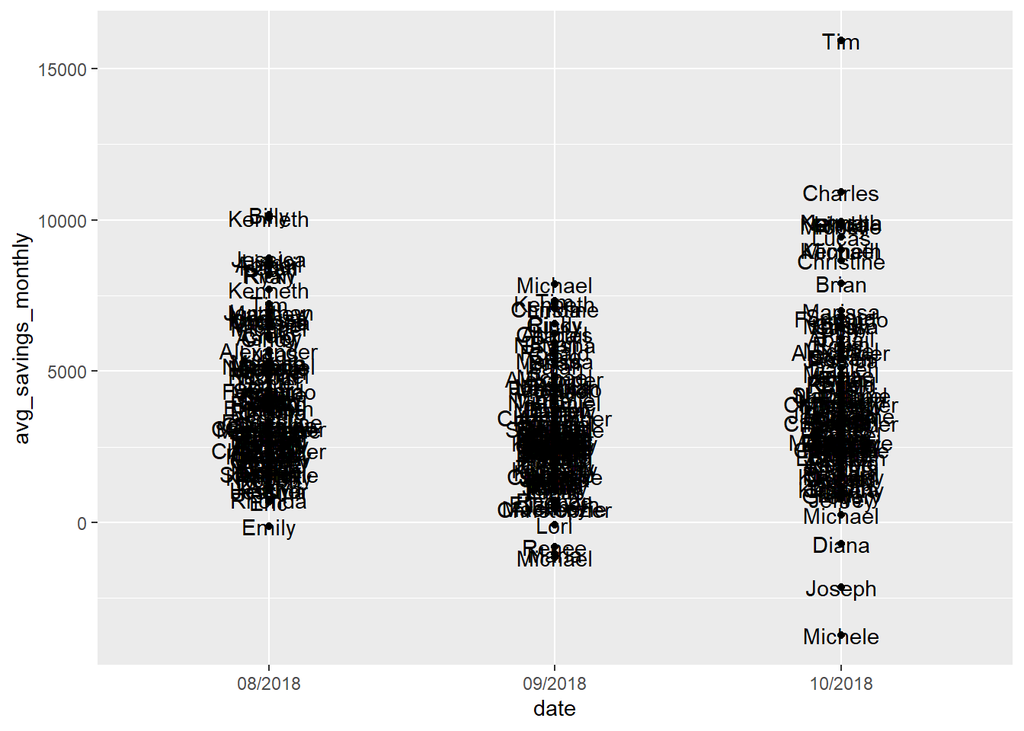

```r
ANZ_sal<-merge(ANZ_cred,ANZ_debit)
ANZ_sal2<-ANZ_sal %>% mutate(avg_savings_monthly = credit - debit) %>% rename(date ="format(date, \"%m/%Y\")")
ANZ_sal2 %>% ggplot(mapping = aes(x=date,y=avg_savings_monthly,label=first_name))+geom_point()+ geom_text()
```

```r
#########cluster analysis
ANZ_sal3<-ANZ_sal2%>% group_by(first_name,account) %>% summarise(credit=sum(credit),debit = sum(debit),savings=sum(avg_savings_monthly))
str(ANZ_sal3)
```

```
## tibble [100 x 5] (S3: grouped_df/tbl_df/tbl/data.frame)
##  $ first_name: chr [1:100] "Abigail" "Alexander" "Amy" "Andrew" ...
##  $ account   : chr [1:100] "ACC-2528867619" "ACC-1890605467" "ACC-414431115" "ACC-721712940" ...
##  $ credit    : num [1:100] 25305 21897 9782 9389 15385 ...
##  $ debit     : num [1:100] 4407 5801 4981 1456 6757 ...
##  $ savings   : num [1:100] 20899 16096 4801 7933 8628 ...
##  - attr(*, "groups")= tibble [80 x 2] (S3: tbl_df/tbl/data.frame)
##   ..$ first_name: chr [1:80] "Abigail" "Alexander" "Amy" "Andrew" ...
##   ..$ .rows     : list<int> [1:80]
##   .. ..$ : int 1
##   .. ..$ : int 2
##   .. ..$ : int 3
##   .. ..$ : int 4
##   .. ..$ : int 5
##   .. ..$ : int 6
##   .. ..$ : int 7
##   .. ..$ : int 8
##   .. ..$ : int 9
##   .. ..$ : int 10
##   .. ..$ : int 11
##   .. ..$ : int 12
##   .. ..$ : int [1:2] 13 14
##   .. ..$ : int 15
##   .. ..$ : int 16
##   .. ..$ : int 17
##   .. ..$ : int 18
##   .. ..$ : int 19
##   .. ..$ : int 20
##   .. ..$ : int 21
##   .. ..$ : int 22
##   .. ..$ : int 23
##   .. ..$ : int 24
##   .. ..$ : int 25
##   .. ..$ : int 26
##   .. ..$ : int 27
##   .. ..$ : int [1:2] 28 29
##   .. ..$ : int 30
##   .. ..$ : int 31
##   .. ..$ : int 32
##   .. ..$ : int 33
```

[output cut: 36 more lines]

```
##   .. ..$ : int 85
##   .. ..$ : int [1:2] 86 87
##   .. ..$ : int 88
##   .. ..$ : int 89
##   .. ..$ : int 90
##   .. ..$ : int 91
##   .. ..$ : int [1:2] 92 93
##   .. ..$ : int 94
##   .. ..$ : int 95
##   .. ..$ : int 96
##   .. ..$ : int 97
##   .. ..$ : int [1:2] 98 99
##   .. ..$ : int 100
##   .. ..@ ptype: int(0)
##   ..- attr(*, ".drop")= logi TRUE
```

```r
names(dplyr::select_if(ANZ_sal3,is.numeric))
```

```
## [1] "first_name" "credit"     "debit"      "savings"
```

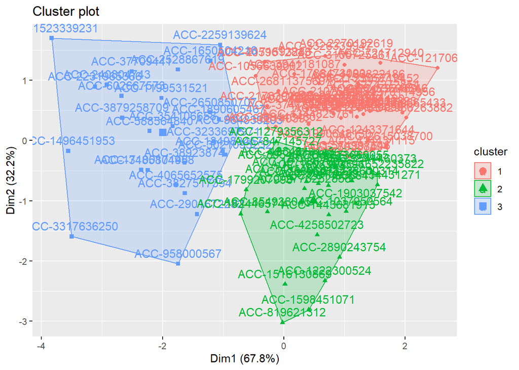

```r
mydata <- scale(ANZ_sal3[,c("credit","debit","savings")])
rownames(mydata) <- ANZ_sal3$account
library(factoextra)
fit <- kmeans(mydata, 3)
fviz_cluster(fit, data = mydata)
```

## Map

```r
library(ggmap)
library(tmap)
library(splitstackshape)
str(ANZ_dataset1)
```

```
## tibble [12,043 x 22] (S3: tbl_df/tbl/data.frame)
##  $ status           : Factor w/ 2 levels "authorized","posted": 1 1 1 1 1 2 1 1 1 2 ...
##  $ card_present_flag: num [1:12043] 1 0 1 1 1 NA 1 1 1 NA ...
##  $ account          : chr [1:12043] "ACC-1598451071" "ACC-1598451071" "ACC-1222300524" "ACC-1037050564" ...
##  $ currency         : Factor w/ 1 level "AUD": 1 1 1 1 1 1 1 1 1 1 ...
##  $ long_lat         : chr [1:12043] "153.41 -27.95" "153.41 -27.95" "151.23 -33.94" "153.10 -27.66" ...
##  $ txn_description  : Factor w/ 6 levels "INTER BANK","PAY/SALARY",..: 5 6 5 6 6 3 6 5 5 1 ...
##  $ merchant_id      : chr [1:12043] "81c48296-73be-44a7-befa-d053f48ce7cd" "830a451c-316e-4a6a-bf25-e37caedca49e" "835c231d-8cdf-4e96-859d-e9d571760cf0" "48514682-c78a-4a88-b0da-2d6302e64673" ...
##  $ first_name       : chr [1:12043] "Diana" "Diana" "Michael" "Rhonda" ...
##  $ balance          : num [1:12043] 35.39 21.2 5.71 2117.22 17.95 ...
##  $ date             : Date[1:12043], format: "2018-08-01" "2018-08-01" ...
##  $ gender           : Factor w/ 2 levels "F","M": 1 1 2 1 1 2 1 1 1 2 ...
##  $ age              : num [1:12043] 26 26 38 40 26 20 43 43 27 40 ...
##  $ merchant_suburb  : Factor w/ 1609 levels "Abbotsford","Aberdeen",..: 53 1380 1380 215 902 NA 709 893 1602 NA ...
##  $ merchant_state   : Factor w/ 8 levels "ACT","NSW","NT",..: 4 2 2 4 4 NA 7 7 8 NA ...
##  $ extraction       : chr [1:12043] "2018-08-01T01:01:15.000+0000" "2018-08-01T01:13:45.000+0000" "2018-08-01T01:26:15.000+0000" "2018-08-01T01:38:45.000+0000" ...
##  $ amount           : num [1:12043] 16.25 14.19 6.42 40.9 3.25 ...
##  $ transaction_id   : chr [1:12043] "a623070bfead4541a6b0fff8a09e706c" "13270a2a902145da9db4c951e04b51b9" "feb79e7ecd7048a5a36ec889d1a94270" "2698170da3704fd981b15e64a006079e" ...
##  $ country          : Factor w/ 1 level "Australia": 1 1 1 1 1 1 1 1 1 1 ...
##  $ customer_id      : chr [1:12043] "CUS-2487424745" "CUS-2487424745" "CUS-2142601169" "CUS-1614226872" ...
##  $ merchant_long_lat: chr [1:12043] "153.38 -27.99" "151.21 -33.87" "151.21 -33.87" "153.05 -26.68" ...
##  $ movement         : Factor w/ 2 levels "credit","debit": 2 2 2 2 2 2 2 2 2 2 ...
##  $ Age_group        : chr [1:12043] "teenage" "teenage" "midage" "midage" ...
```

```r
ANZ_map<-cSplit(ANZ_dataset1, 5, " ", drop=F) %>% rename(longitude_cust = long_lat_1, latitude_cust=long_lat_2)
ANZ_map<-cSplit(ANZ_map, 20, " ", drop=F) %>% rename(longitude_merch = merchant_long_lat_1, latitude_merch=merchant_long_lat_2)
ANZ_map%>% select("longitude_cust","latitude_cust")
```

| longitude_cust | latitude_cust |
| --- | --- |
| 153.41 | -27.95 |
| 153.41 | -27.95 |
| 151.23 | -33.94 |
| 153.10 | -27.66 |
| 153.41 | -27.95 |
| 151.22 | -33.87 |
| 144.95 | -37.76 |
| 144.95 | -37.76 |
| 116.06 | -32.00 |
| 151.23 | -33.96 |

[output cut: 9990 more lines]

```r
ggmap::register_google(key = "AIzaSyBVRB4Dngod3xK-dXAGCTIBIhIg-Pnpl4Y")
myMap <- get_map(location = "Australia", zoom = 4)
```

[figure not shown]

```r
ggmap(myMap)  + geom_point(data = ANZ_map,aes(x = longitude_merch,y = latitude_merch,col='red')) + geom_point(data = ANZ_map%>% select("longitude_cust","latitude_cust"),aes(x = longitude_cust,y = latitude_cust))
```

Most of the merchants are scattered throughout the Australia and Tasmania while users are in populated cities. This is as expected.